# Probability, Statistics and Data Visualization

## Assignment - 5

### -IMF J050

### Lab 5

```python
import torch
import matplotlib.pyplot as plt
import pandas as pd
import numpy as np
import random
from collections import Counter
import ipywidgets as widgets
from ipywidgets import interact
```

### 1. Random Variables

#### Q1 Write a Python function that simulates rolling two six-sided dice and returns their sum. Use this function to perform 10,000 simulations. Calculate and print:

#### a.The experimental probability of rolling a sum of 7

#### b.The experimental probability of rolling a sum of 2 or 12

#### Compare these experimental probabilities with the theoretical probabilities. What conclusions can you draw about the accuracy of the simulation?

```python
import torch
#Definig a function to calculate the sum
def dice_sum(n):
    dice1 = torch.randint(1,7,(n,))#(n,) defining the shape of dice1. dice1 is a Tensor type.
    dice2 = torch.randint(1,7,(n,))
    return dice1+dice2

n=10000;
sample = dice_sum(n)
prob_7 = (sample==7).sum().item()/n# item() is for converting tensor to scalar
prob_2_or_12 = ((sample==2)|(sample==12)).sum().item()/n
the_prob_7 = 6/36
the_prob_2_or_12 = 2/36
print(f'Calculated probability for 7 is {prob_7:.4f} and theoretical probability is {the_prob_7:.4f}')
print(f'Calculated probability for 2 or 12 is {prob_2_or_12:.4f} and theoretical probability is {the_prob_2_or_12:.4f}')
```

```
Calculated probability for 7 is 0.1634 and theoretical probability is 0.1667
Calculated probability for 2 or 12 is 0.0558 and theoretical probability is 0.0556
```

##### Calculated and Theoretical probabilities are almost matching at a accuracy of first 2 digits

### Q2 Write a function coin_toss(n) that simulates flipping a coin n times, returning a list of 'H' (Heads) and 'T' (Tails). Then, write a function count_heads(flips) that takes the list of flips and returns the number of heads (this is your random variable, X). Finally, simulate 10 coin tosses and print the outcome of the coin tosses and the number of heads.

```python
def coin_toss(n):
    flips = torch.randint(0,2,(n,))
    return ["H" if(i==1) else "T" for i in flips]
def count_heads(flips):
    return flips.count("H")
n=10
sample = coin_toss(n)
print(sample)
print(count_heads(sample))
```

```
['H', 'T', 'T', 'T', 'H', 'H', 'T', 'H', 'T', 'T']
4
```

#### Q3 Coin Flip Simulation and Inverse Mapping Check

#### Using the coin_toss(n) and count_heads(flips) functions from Question 1, simulate n = 4 coin flips.

#### Then, given a value a, write a function check_inverse_mapping(flips, a) that checks whether the number of heads in the simulated coin flips equals a. In other words, verify if:

#### X(ξ)=a

#### where:

#### X represents the function that counts the number of heads in the sequence.

#### ξ is the outcome of the 4 coin flips.

#### The function should print whether X(ξ)=a is True or False.

#### Finally, test the function with a = 2.

```python
sample = coin_toss(4)
a = 2
print(sample)
def check_inverse_mapping(sample,a):
    if(sample.count("H") == a) :
        return True
    else :
        return False
print(check_inverse_mapping(sample,a))
```

```
['H', 'H', 'H', 'T']
False
```

### 2. Probalility Mass function

#### Q1. Consider a discrete random variable X with possible values {1, 2, 3, 4, 5}. You are given a function f(x) defined as:

#### f(x)=c(x2−6x+10) for x in {1, 2, 3, 4, 5}

#### where c is a constant.

#### Write a Python function is_valid_pmf(f) that:

#### Determines if f(x) can be a valid PMF for some value of c.

#### If valid, calculates and returns the value of c that makes f(x) a legitimate PMF.If not valid, returns None and prints why it's not valid.

#### Your function should check both properties of a valid PMF:

#### Non-negativity for all x

#### Sum of probabilities equals 1

#### Test your function with the given f(x) and explain your results.

```python
def f(i):
    return (i**2-6*i+10)
X = torch.tensor([1,2,3,4,5])
pmf = f(X)
def is_valid_pmf(f):
    if not(pmf >=0).all():
        return "None some of the probabilities are neagtive"
    if(sum(pmf)==0):
        return "None all the probabilities are zero"
    else:
        return round(1/sum(pmf).item(),4)
print("c = ",is_valid_pmf(f))
```

```
c =  0.0667
```

#### So what we did here is firstly we created a pmf using torch as per given input. Then we passed this pmf to a function is_valid_pmf(). This function first checks that if any element of pmf is negative or not. If it it will be negative the return statement executes and function will end.

#### If all are positive, then we went to find sum of all elements and ignored c. If the sum of elements will be positive, c will be recoprocal of the sum so that the sum of pmf becomes one. If the sum somehow will be zero, then c will be undefined and hence, it will not be valid pmf.

#### In our case, the sum of pmf was 15 which is positive so c became 1/15 and hence the sum of pmf became 1 when multiplied with c

#### Q2. Simulate flipping a coin 100 times and calculate the empirical PMF for the number of heads (0 to 100).

```
Emperical Probability of Heads as per experiment is 0.4900
Emperical Probability of Tails as per experiment is 0.5100
```

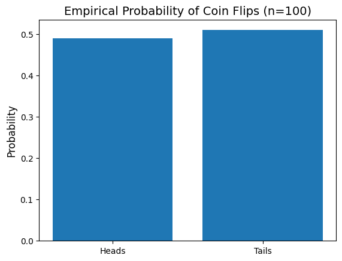

```python
def flips(n):
    sample = torch.randint(0,2,(n,))
    return ["H" if i==1 else "T" for i in  sample]
def count_heads(flips):
    return flips.count("H")
n = 100
prob_heads = (count_heads(flips(100))/100)
print(f"Emperical Probability of Heads as per experiment is {prob_heads:.4f}")
print(f"Emperical Probability of Tails as per experiment is {(1-prob_heads):.4f}")
plt.title(f'Empirical Probability of Coin Flips (n={n})', fontsize=14)
plt.bar(['Heads','Tails'],[prob_heads,1-prob_heads])
plt.ylabel('Probability', fontsize=12)
```

#### Q3. A small café records the number of customers visiting per day for a month (30 days). The recorded data is as follows:

#### customer_counts = [12, 15, 14, 10, 18, 16, 14, 12, 15, 11, 17, 14, 13, 19, 12, 18, 14, 10, 16, 15, 14, 13, 17, 12, 18, 16, 14, 11, 19, 13]

#### Compute the PMF for the given data and plot it using Matplotlib. Identify the most common number of daily customers and compare the distribution.

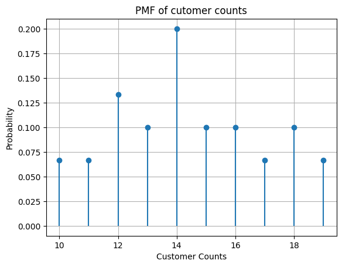

```python
import torch
customer_counts = torch.tensor([12, 15, 14, 10, 18, 16, 14, 12, 15, 11, 17, 14, 13, 19, 12, 18, 14, 10, 16, 15, 14, 13, 17, 12, 18, 16, 14, 11, 19, 13])
X, frequency = torch.unique(customer_counts,return_counts=True)
probability  = frequency/customer_counts.shape[0]
plt.stem(X.numpy(),probability.numpy(), basefmt=" ")
plt.grid(True)
plt.xlabel("Customer Counts")
plt.ylabel("Probability")
plt.title("PMF of cutomer counts")
plt.show()
```

##### Highest Probability is found at 14 Customers. If we take more samples it will approach Poission's Distribution

### 3. Cumulative Distribution Function

#### Q1 Consider a discrete random variable 𝑋 with possible values 𝑥={1,2,3,4,5} and corresponding probability mass function (PMF):

#### P(X=x)=x/15,x∈1,2,3,4,5

#### where 𝑃(𝑋=𝑥) represents the PMF of 𝑋.

#### The Cumulative Distribution Function (CDF) is defined as:

#### FX(x)=P(X≤x)=∑k≤xP(X=k)

#### Your Task:

#### Compute the PMF values for each 𝑥∈{1,2,3,4,5}.

#### Compute the CDF FX(x) for each 𝑥.

#### Verify the relationship between PMF and CDF:

#### P(X=x)=FX(x)−FX(x−1) for all 𝑥≥2.

#### For 𝑥=1, P(X=1)=FX(1) .

#### Print and compare the computed PMF values with the differences in CDF values to confirm the relationship.

```python
X = torch.tensor([1,2,3,4,5])
pmf_X = X/sum(X)
cdf_X = torch.cumsum(pmf_X,dim=0)
diff_cdf_X = (cdf_X[1:]-cdf_X[:-1])
diff_cdf_X = torch.tensor([pmf_X[0]]+diff_cdf_X.tolist())
df = pd.DataFrame({"X": X.numpy(), "PMF": pmf_X.numpy(), "CDF": cdf_X.numpy(),"Difference in CDF": diff_cdf_X })
display(df)
```

|  | X | PMF | CDF | Difference in CDF |
| --- | --- | --- | --- | --- |
| 0 | 1 | 0.066667 | 0.066667 | 0.066667 |
| 1 | 2 | 0.133333 | 0.200000 | 0.133333 |
| 2 | 3 | 0.200000 | 0.400000 | 0.200000 |
| 3 | 4 | 0.266667 | 0.666667 | 0.266667 |
| 4 | 5 | 0.333333 | 1.000000 | 0.333333 |

#### Q2. Write a Python function to compute the CDF for a given discrete probability distribution. Your function should:

#### Take as input:

#### A list or NumPy array of possible values of a discrete random variable.

#### A corresponding list or NumPy array of probability mass function (PMF) values.

#### Return:

#### A list of CDF values corresponding to the input values.

#### Additionally, perform the following:

#### Compute and plot the CDF for a biased 6-sided die, where the probability distribution is:

#### X 3 1 6 2 5 4

#### P(X) 0.15 0.05 0.25 0.10 0.25 0.20

#### Plot the CDF as a step function using Matplotlib.

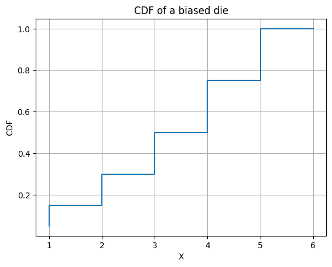

```
FX(X<=1) = 0.05
FX(X<=2) = 0.15
FX(X<=3) = 0.3
FX(X<=4) = 0.5
FX(X<=5) = 0.75
FX(X<=6) = 1.0
```

```python
def cdf(X,pmf):
    X = torch.tensor(X)
    sorted_X = torch.sort(X,descending=False).values
    indices_X = torch.sort(X,descending=False).indices
    pmf = torch.tensor(pmf)
    sorted_pmf = pmf[indices_X]
    cdf = torch.cumsum(sorted_pmf,dim=0)
    return cdf, sorted_X
X = [3,1,6,2,5,4]
pmf_X = [0.15 ,0.05 ,0.25 ,0.10 ,0.25, 0.20]
cdf , X = cdf(X,pmf_X)
plt.step(X,cdf)
plt.xlabel("X")
plt.ylabel("CDF")
plt.grid(True)
plt.title("CDF of a biased die")
plt.show()
for x, cdf in zip(X, cdf):
    print(f"FX(X<={x}) = {round(cdf.item(),2)}")
```

#### Q3 Define a function pdf(x) representing a normal distribution.

#### f(x)=1/(2πσ^2) e^(−(x−μ)^2/2σ^2)

#### Now calcluate the CDF of this function and plot it along with the curve for the above normal distribution

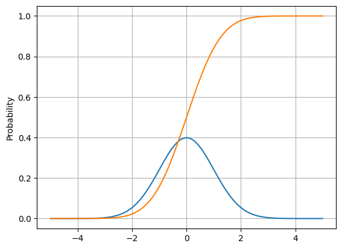

```python
mean = 0
std = 1
normal = torch.distributions.Normal(mean,std)
x = torch.linspace(mean-5*std,mean+5*std,100)
pdf = normal.log_prob(x).exp()
cdf = normal.cdf(x)
plt.plot(x.numpy(),pdf.numpy())
plt.plot(x.numpy(),cdf.numpy())
plt.ylabel("Probability")
plt.grid(True)
plt.show()
```

### 4. Expectation

#### Q1 Simulate a game where you flip a coin three times. The reward system is as follows:

#### $8 for exactly 3 heads

#### $1 for exactly 2 heads,

#### $0 otherwise.

#### The cost to play the game is $1.5. Run the simulation for 10,000 trials and compute the average net gain, compare with theoretical expected net gain?

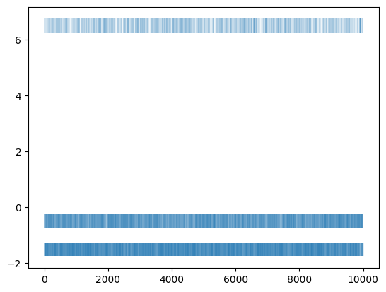

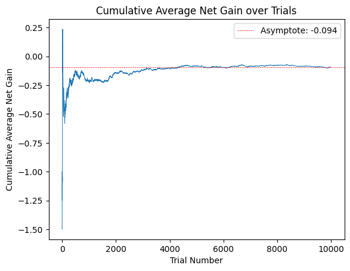

```python
def coin_flips(n):
    flips = torch.randint(0,2,(n,))
    return ["H" if(x==1) else "T" for x in flips]
def count_heads(sample):
    return sample.count("H")
def net_gain(count):
    cost_of_game = 1.5
    if count==3:
        reward = 8
    elif count ==2:
        reward = 1
    else:
        reward = 0
    return reward-cost_of_game
n = 10000
gains=[]
for i in range(n):
    gains.append(net_gain(count_heads(coin_flips(3))))
ymin = [gain - 0.25 for gain in gains]
ymax = [gain + 0.25 for gain in gains]
plt.vlines(range(n), ymin=ymin, ymax=ymax, linewidth=0.1) # Shows the density of gaining 6.5,-0.5 and -1.5
plt.show()
def cumavg(tensor):
    cumsum = torch.cumsum(tensor, dim=0)
    range_tensor = torch.arange(1, len(tensor) + 1)
    return cumsum / range_tensor
gains = torch.tensor(gains)
plt.plot(range(n),cumavg(gains).numpy(),linewidth=0.7)
plt.axhline(y = torch.mean(gains),color = 'r',linewidth=0.5,linestyle='--',label=f'Asymptote: {torch.mean(gains):.3f}')
plt.xlabel("Trial Number")
plt.ylabel("Cumulative Average Net Gain")
plt.title("Cumulative Average Net Gain over Trials")
plt.legend()
plt.show()
```

#### Q2. Write a Python function that computes the expected value of a discrete random variable given its probability mass function (PMF). The function should take a dictionary where keys represent outcomes and values represent their corresponding probabilities.

#### Example:

#### pmf = {1: 0.2, 2: 0.3, 3: 0.5}

#### expected_value = compute_expected_value(pmf)

#### print(expected_value) # Expected Output: 2.3

```python
def expectation(pmf):
    expexted_value =0
    X = list(pmf.keys())
    pmf = list(pmf.values())
    for i in range (0,len(pmf)):
        expexted_value = expexted_value + pmf[i]*X[i]
    return expexted_value
pmf = {1: 0.2, 2: 0.3, 3: 0.5}
print(expectation(pmf))
```

```
2.3
```

#### Using Torch

```python
# Using torch
import torch
def compute_expected_value(pmf):
    X = torch.tensor(list(pmf.keys()),dtype = torch.float32) # Converting both X and pmf to be float so that .dot doesn't give error
    pmf_X = torch.tensor(list(pmf.values()), dtype = torch.float32)
    expected_value = torch.dot(X,pmf_X)  # .dot() calculates expectation, i.e., sigma (X*p)
    return expected_value.item()
pmf = {1: 0.2, 2: 0.3, 3: 0.5}
expected_value = compute_expected_value(pmf)
print("The expected value of the PMF is ",round(expected_value,2))
```

```
The expected value of the PMF is  2.3
```

#### Q3. Given a discrete random variable with its probability mass function (PMF), compute the expected value of a function (g(x)). The function (g(x)) should be provided as input.

#### Example:

#### pmf = {1: 0.2, 2: 0.3, 3: 0.5}

#### g = lambda x: x**2

#### expected_value = compute_expected_value_of_function(pmf, g)

#### print(expected_value)

```python
def expectation(pmf,g):
    expexted_value =0
    X = list(pmf.keys())
    pmf = list(pmf.values())
    for i in range (0,len(pmf)):
        expexted_value = expexted_value + pmf[i]*g(X[i])
    return expexted_value
pmf = {1: 0.2, 2: 0.3, 3: 0.5}
g = lambda x: x**2
print(expectation(pmf,g))
```

```
5.9
```

### 5. Moments and Variance

#### Q1. Write a function to compute the variance of a discrete random variable given its probability mass function.

#### Example:

#### pmf = {1: 0.2, 2: 0.3, 3: 0.5}

#### variance = compute_variance(pmf)

#### print(variance)

```python
def expectation(X,prob):
    expexted_value =0
    for i in range (0,len(X)):
        expexted_value = expexted_value + prob[i]*(X[i])
    return expexted_value
def variance(pmf):
    X = torch.tensor(list(pmf.keys()),dtype = torch.float32)
    prob = torch.tensor(list(pmf.values()), dtype = torch.float32)
    sq_X = [x**2 for x in X]
    return (expectation(sq_X,prob)-expectation(X,prob)**2)
pmf = {1: 0.2, 2: 0.3, 3: 0.5}
print(round(variance(pmf).item(),3))
```

```
0.61
```

#### Q2 Write a function to compute the k-th moment of a discrete random variable given its probability mass function.

#### Example:

#### pmf = {1: 0.2, 2: 0.3, 3: 0.5}

#### k = 3

#### moment = compute_moment(pmf, k)

#### print(moment)

```python
def compute_moment(pmf,k):
    X = torch.tensor(list(pmf.keys()),dtype = torch.float32)
    prob = torch.tensor(list(pmf.values()),dtype = torch.float32)
    moment = torch.dot(X**k, prob)
    return moment
pmf = {1: 0.2, 2: 0.3, 3: 0.5}
k = 3
moment = compute_moment(pmf, k)
print(round(moment.item(),4))
```

```
16.1
```

#### Q3. Simulate and Estimate the variance of a given function ( f(x) ) when ( X ) is uniformly distributed over [a, b].

#### Example:

#### import numpy as np

#### f = lambda x: x**2

#### a, b, N = 0, 1, 10000

#### variance = estimate_variance(f, a, b, N)

#### print(variance)

```python
def estimate_variance(f,a,b,N):
    dist = torch.distributions.Uniform(a,b).sample((N,))
    return torch.var(f(dist))
f = lambda x: x**2
a, b, N = 0, 1, 10000
variance = estimate_variance(f, a, b, N)
print(round(variance.item(),4))
```

```
0.0888
```

### 6. Bernoulli Random Variables

#### Q1 Write a function that simulates a Bernoulli-distributed random variable with a given probability ( p ).

#### Example:

#### p = 0.7

#### outcome = bernoulli_trial(p)

#### print(outcome) # Expected Output: 0 or 1

```python
def bernoulli_trial(p):
    outcome = torch.distributions.Bernoulli(p)
    return outcome.sample().item()
p = 0.7
outcome = bernoulli_trial(p)
print(outcome)
```

```
1.0
```

#### Q2 Given ( p ), the probability of success in a Bernoulli distribution, compute its expectation and variance.

#### Example:

#### p = 0.5

#### expectation, variance = bernoulli_stats(p)

#### print(expectation, variance)

```python
def bernoulli(p):
    dist = torch.distributions.Bernoulli(p)
    expectation = dist.mean.item()
    variance = dist.variance.item()
    return expectation, variance
p=0.5
expectation, variance = bernoulli(p)
print(f"Expectation = {expectation}")
print(f"Variance = {variance}")
```

```
Expectation = 0.5
Variance = 0.25
```

#### Q3. Write a function that simulates N Bernoulli trials and computes the proportion of successes.

#### Example:

#### p = 0.3

#### N = 1000

#### proportion = simulate_bernoulli(p, N)

#### print(proportion)

```python
def simulate_bernoulli(p, N):
    dist = torch.distributions.Bernoulli(p).sample((N,))
    return sum(dist)/N
p = 0.3
N = 1000
proportion = simulate_bernoulli(p, N)
print(f'Success proportion is {round(proportion.item(),2)}')
```

```
Success proportion is 0.32
```

### 7. Binomial Distribution

#### Q1. Write a Python function that simulates a Binomial random variable. The function should take three inputs:

#### n (number of trials)

#### p (probability of success)

#### size (number of random values to generate)

#### Plot a histogram of the generated values for n=10, p=0.5, and size=1000.

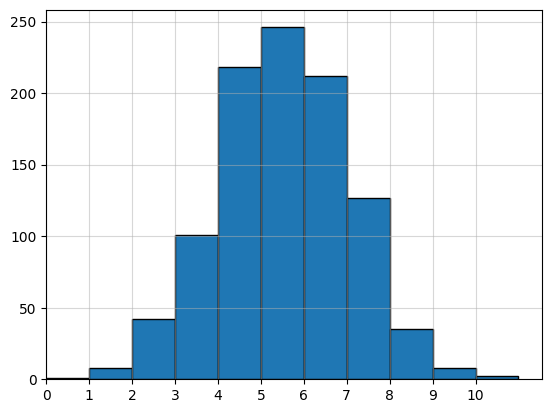

```python
def binomial(n,p,N):
    dist = torch.distributions.Binomial(n,p).sample((N,))
    plt.hist(dist,bins=range(n+2),edgecolor='k')
    plt.grid(True,alpha=0.5)
    plt.xticks(range(11))
    plt.xlim(0)
binomial(10,0.5,1000)
```

#### Q2 Write a Python program that:

#### a. Computes the probability mass function (PMF) of a Binomial distribution.

#### b. Plots the PMF for n=20 and p=0.3.

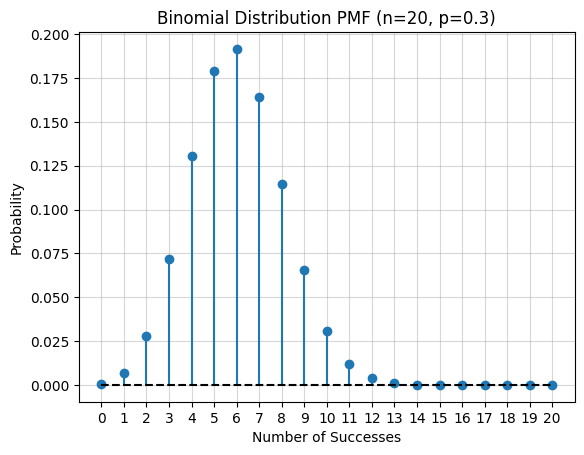

```python
def binomial_pmf(n,p,N):
    dist = torch.distributions.Binomial(n,p)
    outcomes = torch.arange(0, n + 1) # Convert to PyTorch tensor
    probabilities = dist.log_prob(outcomes).exp()

    plt.stem(outcomes.numpy(), probabilities.numpy(),basefmt='k--')#To remove the bottom red line.
    plt.grid(True, alpha=0.5)
    plt.xlabel('Number of Successes')
    plt.ylabel('Probability')
    plt.xticks(range(0,21))
    plt.title(f'Binomial Distribution PMF (n={n}, p={p})')
    plt.show()
binomial_pmf(20, 0.3, 1000)
```

#### Q3. Simulate a fair coin being flipped 100 times and count the number of heads. Repeat this experiment 1000 times and visualize the distribution using a histogram. Explain how this relates to the Binomial distribution.

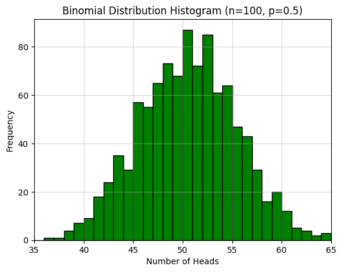

```python
def binomial(n,p,N):
    dist = torch.distributions.Binomial(n,p).sample((N,))
    outcomes = torch.arange(0,n+1)

    plt.hist(dist,bins = range(0,n),edgecolor='k',color='g')
    # Zoom in on the middle part
    mean = n * p
    std_dev = (n * p * (1 - p)) ** 0.5
    plt.xlim(mean - 3 * std_dev, mean + 3 * std_dev)
    plt.xlabel('Number of Heads')
    plt.ylabel('Frequency')
    plt.title(f'Binomial Distribution Histogram (n={n}, p={p})')
    plt.grid(True,alpha=0.5)
    plt.show()

binomial(100,0.5,1000)
```

#### This clearly relates to the Binomial Distribution as we are flipping a coin 100 times, i.e., if X is a random variable of number of heads then, X~Binomial(n=100,p=0.5). It calculates the number of successes (heads) in a fixed number of independent trials (flips), where each trial has the same probability of success, i.e., getting a head (0.5).

### 8. Geometric Distribution

#### Q1. Simulating Geometric Distribution

#### Write a Python function that generates random numbers from a Geometric distribution. The function should take:

#### p (probability of success)

#### size (number of values to generate)

#### Plot a histogram for p=0.3 and size=1000.

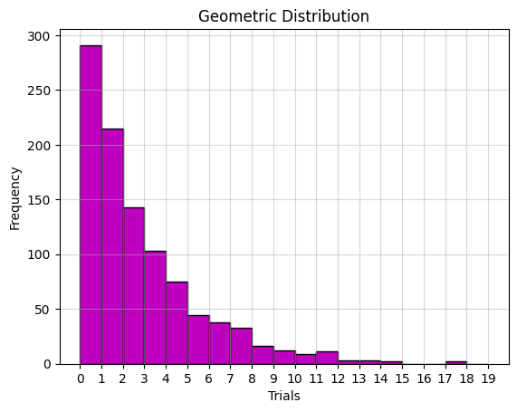

```python
def geometric(p,N):
    dist = torch.distributions.Geometric(p).sample((N,))
    plt.hist(dist,bins=range(20),color='m',edgecolor='k')
    plt.grid(True, alpha=0.5)
    plt.xticks(range(20))
    plt.xlabel("Trials")
    plt.ylabel("Frequency")
    plt.title("Geometric Distribution")
    plt.show()
geometric(0.3,1000)
```

#### Q2. Expected Number of Trials

#### Create an interactive Python program that uses ipywidgets and matplotlib to visualize the probability mass function (PMF) of the Geometric distribution. Users can adjust the probability of success ( p ) and the maximum number of trials ( k ) to display.

```python
import torch
import matplotlib.pyplot as plt
import numpy as np
from ipywidgets import interact, FloatSlider, IntSlider

def geometric_pmf(p, k_max):
    # Generate outcomes (1 to k_max)
    outcomes = np.arange(1, k_max + 1)

    # Calculate PMF: P(X = k) = (1 - p)^(k-1) * p
    probabilities = (1 - p) ** (outcomes - 1) * p

    # Plot the PMF
    plt.figure(figsize=(8, 5))
    plt.stem(outcomes, probabilities)
    plt.grid(True, alpha=0.5)
    plt.xlabel("Number of Trials")
    plt.ylabel("Probability")
    plt.title(f"Geometric Distribution PMF (p={p:.2f})")
    plt.xticks(np.arange(1, k_max + 1))
    plt.xlim(0.5, k_max + 0.5)
    plt.ylim(0, max(probabilities) * 1.2)
    plt.show()

# Interactive widgets for probability and maximum trials
interact(
    geometric_pmf,
    p=FloatSlider(value=0.3, min=0.01, max=1.0, step=0.01, description="p"),
    k_max=IntSlider(value=20, min=5, max=50, step=1, description="Max Trials")
)
```

```
interactive(children=(FloatSlider(value=0.3, description='p', max=1.0, min=0.01, step=0.01), IntSlider(value=2…
```

```
<function __main__.geometric_pmf(p, k_max)>
```

#### Q3. Estimating p from Sample Data

#### Generate a dataset of 500 Geometric random variables with p=0.4. Then, estimate p from the data using the formula:

#### p^=1/sample mean

#### Compare the estimated value with the true p=0.4 and compute the percentage error.

```python
prob = 0.4
N = 500
dist = torch.distributions.Geometric(prob).sample((N,))
mean = dist.mean()
estimated_prob = 1/mean
error = ((prob-estimated_prob)/prob)*100
print(f"Estimated value is {round(estimated_prob.item(),2)}")
print(f"Percentage error in probabillity is {round(abs(error.item()),4)}%")
```

```
Estimated value is 0.65
Percentage error in probabillity is 63.6126%
```

### 9. Poisson Distribution

#### Q1. Write a Python function that generates Poisson random variables. The function should take:

#### λ (expected number of events per interval)

#### size (number of values to generate)

#### Plot a histogram for λ=5 and size=1000.

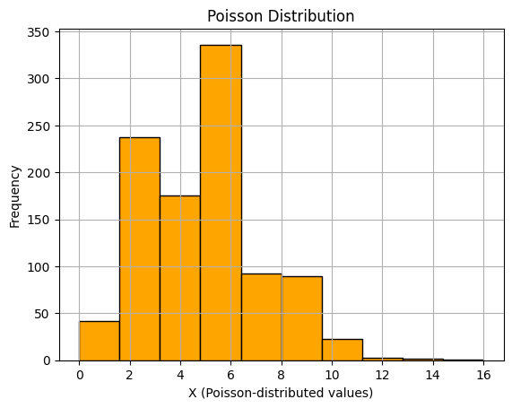

```python
def Poisson(λ,n):
    dist = torch.distributions.Poisson(λ)
    sample = dist.sample((n,))
    return sample
λ = 5
n = 1000
dist =  Poisson(λ,n)
plt.hist(dist,edgecolor = "k",color = "orange",bins=10)
plt.xlabel("X (Poisson-distributed values)")
plt.ylabel("Frequency")
plt.title("Poisson Distribution")
plt.grid(True)
plt.show()
```

#### Q2. Generate 1000 samples from a Binomial distribution with n=100 and p=0.05. Then, generate 1000 samples from a Poisson distribution with λ=n*p=5. Compare their histograms and explain why the Poisson distribution approximates the Binomial distribution for large n and small p.

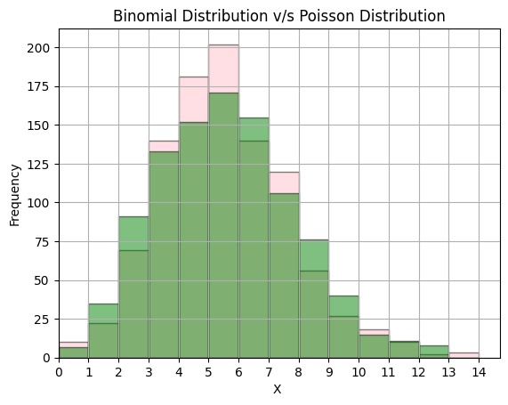

```python
N = 1000
n = 100
p = 0.05
lamda = 5
binomial_dist = torch.distributions.Binomial(n,p).sample((N,))
Poisson_dist = torch.distributions.Poisson(lamda).sample((N,))
plt.hist(binomial_dist,bins=range(15),edgecolor='k',color = 'pink',alpha=0.5)
plt.hist(Poisson_dist,bins=range(15),edgecolor='k',color = 'green',alpha=0.5)
plt.xlabel("X ")
plt.ylabel("Frequency")
plt.title("Binomial Distribution v/s Poisson Distribution")
plt.xticks(range(15))
plt.xlim(0)
plt.grid(True)
plt.show()
```

#### So we can see that at high samples almost 1000 the bins of Poisson are overlapping those of Binomial. This shows that at very large values of n the Binomial Distribution gets approximated to Poisson Distribution

#### Q3.A call center receives calls at an average rate of 3 calls per minute. Assume the number of calls follows a Poisson distribution.

#### Compute the probability of receiving exactly 5 calls in a minute.

#### Compute the probability of receiving at most 5 calls.

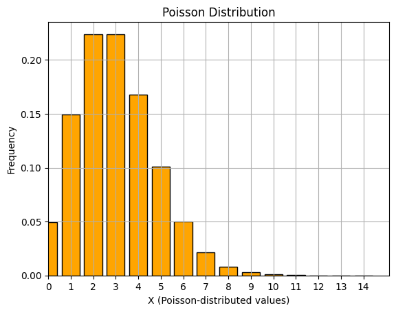

```
Probability of 5 calls is 0.1008
Probability of atmost 5 calls is 0.9161
```

```python
lamda = 3
N = 1000
dist = torch.distributions.Poisson(lamda)
samples = dist.sample((N,))
outcomes = torch.arange(0,15)
probability = dist.log_prob(outcomes).exp()
plt.bar(outcomes.numpy(),probability.numpy(),edgecolor='k',color='orange')
plt.xlabel("X (Poisson-distributed values)")
plt.ylabel("Frequency")
plt.title("Poisson Distribution")
plt.xticks(range(15))
plt.xlim(0)
plt.grid(True)
plt.show()
print(f"Probability of 5 calls is {round(probability[5].item(),4)}")
print(f"Probability of atmost 5 calls is {round(probability[:6].sum().item(),4)}")
```

### 10. Probability Density function

#### Q1 Implement a piecewise PDF defined as:

#### f(x)= { 0.5x if 0≤x≤1; 2-x if 1<x≤2; 0 otherwise }

#### Compute P(0.5≤X≤1.5) analytically and verify using numerical integration.

#### Plot the PDF and highlight the area under the curve for the computed probability.

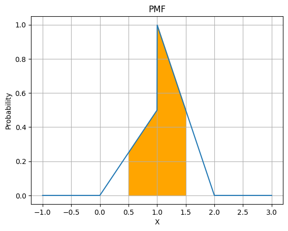

```
The P(0.5<=X<=1.5) using Numerical Integration is  0.5625
```

```python
import numpy as np
def pdf(x):
    return torch.where((x>=0) &( x<1), 0.5*x,
    torch.where((x>=1) & (x<=2), 2-x,
    torch.tensor(0.0)))
x = torch.linspace(-1,3,1000)
X = torch.linspace(0.5,1.5,1000)
plt.plot(x.numpy(),pdf(x).numpy())
plt.fill_between(X,pdf(X),color='orange')
plt.ylabel("Probability")
plt.xlabel("X")
plt.title("PMF")
plt.grid(True)
plt.show()
prob_X = torch.trapz(pdf(X),X) # Same as Numerical Integration in Pytorch: Integral over X of f(x)dx
print("The P(0.5<=X<=1.5) using Numerical Integration is ",round(prob_X.item(),4))
```

#### Q2. Write a Python program to estimate the probability density function of a given dataset using a histogram.

#### Generate or load a dataset (e.g., from a normal distribution with mean = 0 and standard deviation = 1, sample size = 1000).

#### Compute the histogram with an appropriate number of bins.

#### Normalize the histogram so that it represents a probability density function and plot the estimated PDF.

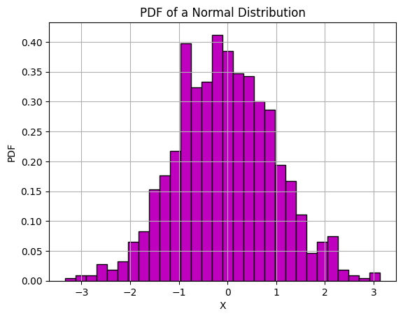

```python
mean = 0
std = 1
N = 1000
normal = torch.distributions.Normal(mean,std)
samples = normal.sample((N,))
plt.hist(samples.numpy(),color='m',edgecolor="k",density=True,bins=30)
plt.xlabel("X")
plt.ylabel("PDF")
plt.title("PDF of a Normal Distribution")
plt.grid(True)
plt.show()
```

#### Q3 Random variable X defined as:

#### Discrete PMF: P(X=0)=0.2.

#### Continuous PDF: For 1≤x≤3, f(x)=0.4.

#### X is undefined outside {0}∪[1,3].

#### a) Confirm the total probability is 1.

#### b) Compute P(1.5≤X≤2.5).

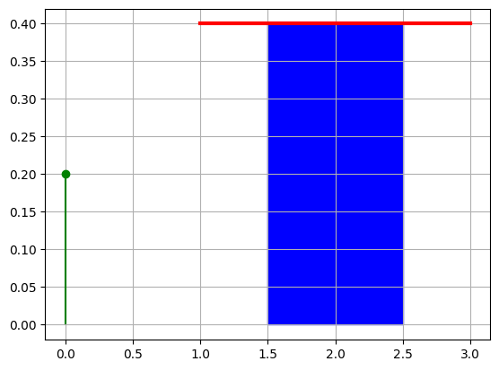

```
Total probability is 0.2+0.4*2=1
The P(1.5<=X<=2.5) using Numerical Integration is  0.4
```

```python
x_discrete = 0
p_discrete = 0.2
x_cont = torch.linspace(1,3,1000)
p_cont = torch.full(x_cont.shape,0.4)
plt.plot(x_cont.numpy(),p_cont.numpy(),color='red',linewidth=3)
plt.stem(x_discrete,p_discrete,linefmt='green')
X = torch.linspace(1.5,2.5,100)
plt.fill_between(X,torch.full(X.shape,0.4),color='blue')
plt.grid(True)
plt.show()
prob_X = torch.trapz(torch.full(X.shape,0.4),X) # Same as Numerical Integration in Pytorch: Integral over X of f(x)dx
print("Total probability is 0.2+0.4*2=1")
print("The P(1.5<=X<=2.5) using Numerical Integration is ",round(prob_X.item(),4))
```

### 11. Expectation(continuous)

#### Q1. Implement a function to compute E[X] for a continuous random variable with a piecewise probability density function (PDF).

```python
import torch
def expectation(intervals,funcs):
    expectation = 0
    for (a,b),f in zip(intervals, funcs):
        X = torch.linspace(a,b,100)
        expectation +=torch.trapz(f(X),X)
    return expectation
def f1(x): return x
def f2(x): return 2-x
print("The expectation of PDF is ", expectation([(0, 1), (1, 2)], [f1, f2]).item())
```

```
The expectation of PDF is  1.0
```

#### Q2. Compute E[g(X)] for a continuous random variable X with PDF f(x) and transformation g, using numerical integration.

```python
def expectation_transform(g, pdf, lower, upper):
    X = torch.linspace(lower,upper,1000)
    expectation = torch.trapz(pdf(X)*g(X),X)
    return expectation
f = lambda x: 2*x  # PDF for X ~ Uniform(0,1) transformed by Y=2X
print("E[g(x)] value is",round(expectation_transform(lambda x: x, f, 0, 1).item(),3))
```

```
E[g(x)] value is 0.667
```

### 12. Cumulative distribution function for continuous random variables

#### Q1 Write a function to compute and plot the Cumulative Distribution Function (CDF) for a Uniform continuous random variable 𝑋 ∼ 𝑈(𝑎,𝑏) given the probability density function (PDF):

#### fX(x)={1/b−a a≤x≤b; 0 otherwise }

#### Your function should:

#### Take a and b (where 𝑎 < 𝑏) as inputs.

#### Compute the CDF FX(x)

#### Generate an array of 𝑥-values and compute FX(x) .

#### Plot the CDF curve using Matplotlib.

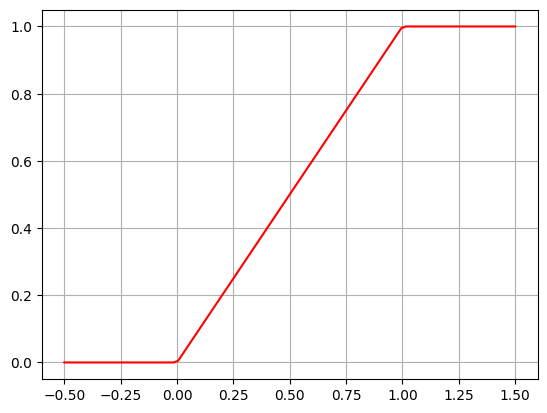

```python
def cdf_uniform(a,b):
    c = (b-a)/2
    X = torch.linspace(a-c,b+c,100)
    cdf = torch.where(X < a, torch.tensor(0.0), torch.where((a <= X ) & (X <= b), (X-a)/(b-a),torch.tensor(1.0)))
    plt.plot(X.numpy(), cdf.numpy(),color='r')
    plt.grid(True)
a = int(input())
b = int(input())
cdf_uniform(a, b)
```

#### Q2 A continuous random variable 𝑋 follows an Exponential distribution with a given rate parameter 𝜆. The probability density function (PDF) of 𝑋 is:

#### fX(x)=λe^(−λx),x≥0

#### Your task is to derive and compute the CDF FX(x) of the given exponential distribution for a given 𝜆.

#### Instructions:

#### Write a function that takes 𝑥 and 𝜆 as input and returns the cumulative distribution function (CDF) FX(x) .

#### Compute the CDF for different values of 𝑥 in the range [0, 5].

#### Plot the CDF curve for a given 𝜆.

```
CDF at x=5: 0.9999545812606812
```

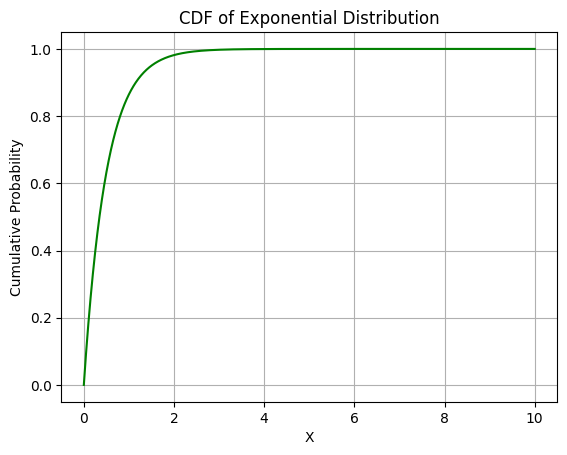

```python
def cdf_exp(x,lamda):
    exp = torch.distributions.Exponential(lamda)
    cdf = exp.cdf(x)
    return cdf

X = torch.linspace(0,10,1000)
plt.plot(X,cdf_exp(X,2),color='green')
plt.xlabel("X")
plt.ylabel("Cumulative Probability")
plt.title("CDF of Exponential Distribution")
plt.grid(True)
print("CDF at x=5:", cdf_exp(torch.tensor(5.0), 2).item())
```

#### Q3 A continuous random variable 𝑋 follows an Exponential distribution with a rate parameter 𝜆. The PDF of 𝑋 is given as:

#### fX(x)=λ*e^−(λx),x≥0

#### Your task is to compute the probability 𝑃(1≤𝑋≤3) using two different approaches:

#### (a) PDF Approach: Compute the probability using numerical integration of the PDF over the interval [1,3].

#### (b) CDF Approach: Compute the probability using the CDF formula.

```python
lamda = 1
exp = torch.distributions.Exponential(lamda)
def pdf_exp(a,b,lamda):
    X = torch.linspace(a,b,100)
    pdf = exp.log_prob(X).exp()
    cdf = torch.trapz(pdf,X)
    return cdf
print("The probability P(1<=X<=3) using pdf approach is ",round(pdf_exp(1,3,lamda).item(),4))
prob_dist_cdf = exp.cdf(torch.tensor(3)) - exp.cdf(torch.tensor(1))
print("The probability P(1<=X<=3) using cdf approach is ",round(prob_dist_cdf.item(),4))
```

```
The probability P(1<=X<=3) using pdf approach is  0.3181
The probability P(1<=X<=3) using cdf approach is  0.3181
```

### 13. Mean, Mode, and Median

#### Q1. Compute Summary Statistics:

#### Using a numerical dataset, write a Python snippet to compute the mean, median, and mode using built-in libraries.

```python
import torch
data = torch.tensor([12, 15, 12, 10, 18, 20, 12, 15, 22, 18])
print("Mean of data is",round(torch.mean(data.float()).item(),2))
print("Median of data is",torch.median(data.float()).item())
print("Mode of data is",torch.mode(data.float()).values.item())
```

```
Mean of data is 15.4
Median of data is 15.0
Mode of data is 12.0
```

#### Q2. Visualize Distribution with Markers:

#### Generate a sample (e.g., from a normal distribution) and plot its histogram. Then mark the mean (red), median (green), and an approximate mode (blue, as the bin with maximum count) on the plot.

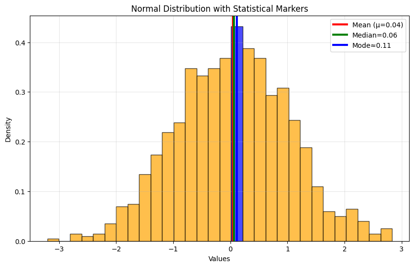

```python
data = torch.normal(mean=0.0, std=1.0, size=(1000,))
mean = torch.mean(data).item()
median = torch.median(data).item()
plt.figure(figsize=(10, 6))
n, bins, patches = plt.hist(data.numpy(), bins=30, density=True,
                            alpha=0.7, color='orange', edgecolor='black')
max_bin_index = n.argmax()
for i in range(len(patches)):
    if i == max_bin_index:
        patches[i].set_facecolor('blue')  # Color the mode bin blue
plt.axvline(mean, color='red', linewidth=3,
           label=f'Mean (μ={mean:.2f})')
plt.axvline(median, color='green', linewidth=3,
           label=f'Median={median:.2f}')
mode = (bins[max_bin_index] + bins[max_bin_index + 1]) / 2
plt.axvline(mode, color='blue', linewidth=3,
           label=f'Mode≈{mode:.2f}')
plt.title('Normal Distribution with Statistical Markers')
plt.xlabel('Values')
plt.ylabel('Density')
plt.grid(alpha=0.3)
plt.legend()
plt.show()
```

#### Q3. Sample vs. Theoretical Comparison:

#### Generate 1000 samples from a known distribution (e.g., Uniform over [0, 10]) and compute the sample mean, median, and mode. Compare these with the theoretical values (mean = 5, median = 5).

```python
uniform = torch.distributions.Uniform(0,10).sample((1000,))
print("Mean is",round(uniform.mean().item(),2))
print("Median is",round(uniform.median().item(),2))
print(f"Mode is {round(uniform.mode().values.item(),4)}. This mode doesn't have any significance")
print("Mean and Median are almost tending to the actual values. We will get closer values if we increase the sample size. But mode of a uniform distribution is every value in given range as all values have equal probability.The mode value found out by sample values doesn't have any physical significance it is just a random value.")
```

[output not shown]

### 14. Uniform Random Variables

#### Q1. Simulate and Plot PDF & CDF:

#### Simulate a Uniform random variable over [2, 5] and plot its PDF and CDF using matplotlib, matching the formulas in the slide.

[figure not shown]

```python
uniform = torch.where((X >= 2) & (X <= 5), 1/3, torch.tensor(0.0))
cdf = torch.where(
        X < 2, torch.tensor(0.0),
        torch.where(X > 5, torch.tensor(1.0), (X - 2) / 3) )
X = torch.linspace(0,7,1000)
plt.plot(X, uniform)
plt.plot(X, cdf)
plt.grid(True)
```

#### Q2. Compute Theoretical Moments:

#### Calculate the theoretical mean and variance for a Uniform(a, b) random variable with a = 2 and b = 5 using the formulas from the slide.

```python
a=2
b=5
mean = (a+b)/2
variance = (b-a)**2/12
print(f'Mean={mean}')
print(f'Variance={variance}')
```

```
Mean=3.5
Variance=0.75
```

#### Q3. Probability Calculation Using CDF:

#### For X ∼ Uniform(2, 5), compute P[3 ≤ X ≤ 4] using the CDF approach described in the slide.

```python
uniform = torch.distributions.Uniform(2,5)
cdf_4 = uniform.cdf(torch.tensor(4))
cdf_3 = uniform.cdf(torch.tensor(3))
print("P[3<=X<=4] using cdf approach is",round((cdf_4 - cdf_3).item(),2))
```

```
P[3<=X<=4] using cdf approach is 0.33
```

### 15. Exponential Random Variables

#### Q1 Simulate and Overlay Theoretical PDF:

#### Simulate 1000 samples from an Exponential(λ = 0.5) distribution, then plot a histogram of the samples with the theoretical PDF overlay.

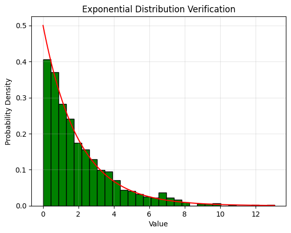

```python
import matplotlib.pyplot as plt
lamda = 0.5
exp = torch.distributions.Exponential(lamda)
samples = exp.sample((1000,))
X = torch.linspace(0,samples.max(), 1000)
pdf = exp.log_prob(X).exp()
plt.hist(samples,edgecolor='k',bins=30,color='green',density=True)
plt.plot(X.numpy(), pdf.numpy(),color='red')
plt.grid(True)
plt.title('Exponential Distribution Verification')
plt.xlabel('Value')
plt.ylabel('Probability Density')
plt.grid(True, alpha=0.3)
plt.show()
```

#### Q2. Theoretical Mean and Variance:

#### Using the formulas from the slide, compute the theoretical mean and variance for an Exponential distribution with λ = 0.5.

```python
mean = 1/lamda
variance = 1/(lamda**2)
lamda = 0.5
print("Mean is",mean)
print("Variance is",variance)
```

```
Mean is 2.0
Variance is 4.0
```

#### Q3. Compute Tail Probability:

#### For an Exponential(λ = 0.5) random variable, calculate P[T > 3] using the survival function (i.e. 1 – CDF) as derived in the slide.

```python
lamda = 0.5
exp = torch.distributions.Exponential(lamda)
cdf_3 = exp.cdf(torch.tensor(3))
print("P[T > 3] is",round(1-(cdf_3).item(),2))
```

```
P[T > 3] is 0.22
```

### 16. Gaussian Random Variables

#### Q1. The PDF of a Gaussian random variable X∼N(μ,σ2) is given by:

#### fX(x)=(1/root(2πσ^2)). exp((−(x−μ)^2)/2σ^2).

#### 1. Use torch.distributions, generate 100 random samples from a Gaussian distribution with a mean of 3 and a standard deviation of 2.

#### 2. Plot a histogram of the samples and calculate the sample mean and variance of the distribution.

#### 3. Repeat this process for sample sizes of 10000 and 1000000.

#### Observe how the shape of the histogram changes as the sample size increases. What patterns or trends do you notice in the calculated sample mean and variance?

[figure not shown]

```
Mean in 3 cases is 3.08 3.0 3.0
Variance in 3 cases is 3.76 3.94 3.99
```

```python
mean = 3
std = 2
Gaussian = torch.distributions.Normal(mean,std)
samples_100= Gaussian.sample((100,))
mean_100 = samples_100.mean().item()
variance_100 = samples_100.var().item()

samples_10000 = Gaussian.sample((10000,))
mean_10000 = samples_10000.mean().item()
variance_10000 = samples_10000.var().item()

samples_1000000 = Gaussian.sample((1000000,))
mean_1000000 = samples_1000000.mean().item()
variance_1000000 = samples_1000000.var().item()

fig, ax = plt.subplots(3,1,figsize=(6,10))
ax[0].hist(samples_100,bins=20,edgecolor='k',color='m')
ax[0].set_xlabel("Samples X")
ax[0].set_ylabel("Probability Density")
ax[0].set_title("Histogram of Gaussian Distribution for n = 100")

ax[1].hist(samples_10000,bins=20,edgecolor='k',color='green')
ax[1].set_xlabel("Samples X")
ax[1].set_ylabel("Probability Density")
ax[1].set_title("Histogram of Gaussian Distribution for n = 100000")

ax[2].hist(samples_1000000,bins=20,edgecolor='k',color='orange')
ax[2].set_xlabel("Samples X")
ax[2].set_ylabel("Probability Density")
ax[2].set_title("Histogram of Gaussian Distribution for n = 10000000")
plt.tight_layout()
plt.show()
print("Mean in 3 cases is",round(mean_100,2),round(mean_10000,2),round(mean_1000000,2))
print("Variance in 3 cases is",round(variance_100,2),round(variance_10000,2),round(variance_1000000,2))
```

#### We can see in the calculated mean and variance for different sizes that as the size of samples grow, the mean and variance of sample tends to 3 and 4 respectively which is equal to theoretical mean and variance. Hence, at furthur larger values of n, it coincides with the theoretical value

#### Q2 Let X∼N(0,1) be a standard Gaussian random variable. Define a new random variable Y=4X+10 . What is the distribution of Y ? Verify your answer by ploting histogram of random variable Y . You can use torch.distributions for generating samples for Gaussian random vairable.

```
We can see that both the histtograms are same but only numbers on x-axis are changed.Hence even the new distribution is also a gaussian distribution.
```

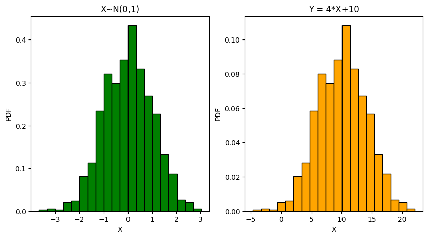

```python
X = torch.distributions.Normal(0,1)
samples = X.sample((1000,))
fig,ax = plt.subplots(1,2,figsize=(10,5))
ax[0].hist(samples,edgecolor='k',color='green',bins=20,density = True)
ax[0].set_title("X∼N(0,1)")
ax[0].set_xlabel("X")
ax[0].set_ylabel("PDF")
new_samples = 4*samples+10
ax[1].hist(new_samples,edgecolor='k',color='orange',bins=20,density = True)
ax[1].set_title("Y = 4*X+10")
ax[1].set_xlabel("X")
ax[1].set_ylabel("PDF")
print("We can see that both the histtograms are same but only numbers on x-axis are changed.Hence even the new distribution is also a gaussian distribution.")
```

#### So, we can see that X is a standard Normal Gaussian distribution with centered around 0 (as mean is 0). And in addition to it, Y is also a Normal Gaussian Distribution but centered around 10 (This shows it mean is around 10). Hence Y is also a Gaussian Distribution

#### Q3 Let X∼N(μ1,σ1^2 with μ1=3 and σ1=2 , and let Y∼N(μ2,σ2^2) with μ2=−1 and σ2=1 . Define a new random variable Z=X+Y .

#### 1. Determine the theoretical mean and variance of Z. Write this in a markdown cell.

#### 2. Verify the theoretical mean and variance that you get by generating 10,000 samples for 𝑋 and 𝑌 using torch.distributions and computing their sum to get 𝑍. Print the empirical mean and variance of 𝑍.

#### 3. Plot histogram of the distribution of random variable 𝑍.

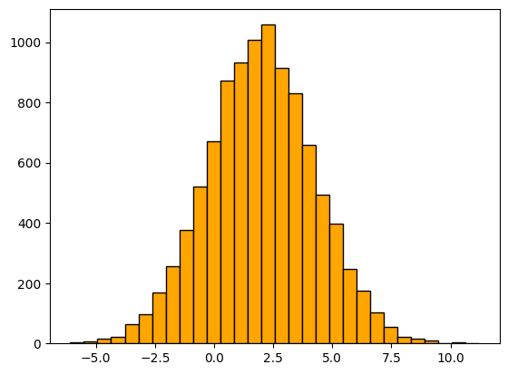

```
Mean is  1.98
Variance is  5.14
Theoritical Mean is 2
Theoritical Varinace is 5
```

```python
import torch
import matplotlib.pyplot as plt
mean1 = 3
std1 = 2
normal1 = torch.distributions.Normal(mean1,std1)
samples1 = normal1.sample((10000,))
mean2 = -1
std2 = 1
normal2 = torch.distributions.Normal(mean2,std2)
samples2 = normal2.sample((10000,))
samples = samples1+samples2
plt.hist(samples,bins=30,edgecolor='k',color='orange')
plt.show()
print("Mean is ",round(samples.mean().item(),2))
print("Variance is ",round(samples.var().item(),2))
print("Theoritical Mean is",mean1+mean2)
print("Theoritical Varinace is",std1**2+std2**2)# as 1 and 2 are independent events covarinace is 0.
```

### 17. Transformation of random Variables

#### Q1. Write a function that performs the following tasks:

#### Generate 10,000 samples from a uniform distribution in the range [0, 1].

#### Apply a linear transformation Y = 2X + 3 to the generated samples.

#### Plot the histogram of the original samples and the transformed samples side by side.

#### Calculate and print the mean and variance of both the original and transformed distributions.

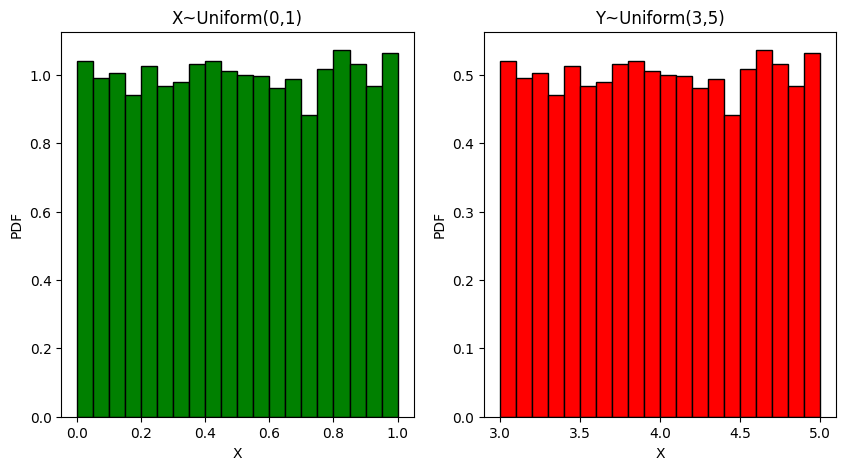

```
Mean of X is 0.5
Mean of Y is 4.0
Variance of X is 0.08
Variance of Y is 0.34
```

```python
X = torch.distributions.Uniform(0,1)
samples_X = X.sample((10000,))
samples_Y = 2*samples_X+3
fig, ax = plt.subplots(1,2,figsize=(10,5))
ax[0].hist(samples_X,bins=20,edgecolor='k',color='green',density=True)
ax[0].set_xlabel("X")
ax[0].set_ylabel("PDF")
ax[0].set_title(f"X~Uniform(0,1)")

ax[1].hist(samples_Y,bins=20,edgecolor='k',color='red',density=True)
ax[1].set_xlabel("X")
ax[1].set_ylabel("PDF")
ax[1].set_title(f"Y~Uniform(3,5)")
plt.show()
print("Mean of X is",round(torch.mean(samples_X).item(),2))
print("Mean of Y is",round(torch.mean(samples_Y).item(),2))
print("Variance of X is",round(torch.var(samples_X).item(),2))
print("Variance of Y is",round(torch.var(samples_Y).item(),2))
```

#### Q2. Let X be a continuous random variable following a Uniform(0,1) distribution. Define a new random variable: Y=−ln(X)

#### (a). Generate 10,000 samples of X and compute Y.

#### (b). Plot the histogram of Y, and compare it with the probability density function (PDF) of an exponential distribution with parameter λ=1/2.

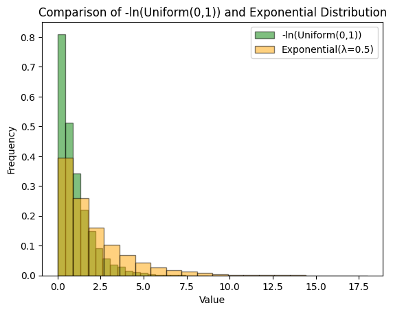

```python
X = torch.distributions.Uniform(0,1)
samples_X = X.sample((10000,))
samples_Y = -torch.log(samples_X)
plt.hist(samples_Y,bins=20,edgecolor='k',color='green',alpha=0.5,label='-ln(Uniform(0,1))',density = True)
lamda=0.5
exp = torch.distributions.Exponential(lamda)
samples = exp.sample((10000,))
plt.hist(samples.numpy(),bins=20,edgecolor='k',color='orange',alpha=0.5,label='Exponential(λ=0.5)',density = True)
plt.title('Comparison of -ln(Uniform(0,1)) and Exponential Distribution')
plt.xlabel('Value')
plt.ylabel('Frequency')
plt.legend()
plt.show()
```

#### Q3 Combined Transformation Involving a Logarithmic Function

#### Let X∼N(0,1) and define a new random variable Z=ln(|X|+1) .

#### Use torch.distributions to simulate 10,000 samples of X , compute Z , and estimate its empirical distribution.

#### Plot the histogram of Z and compare it with the histogram of X .

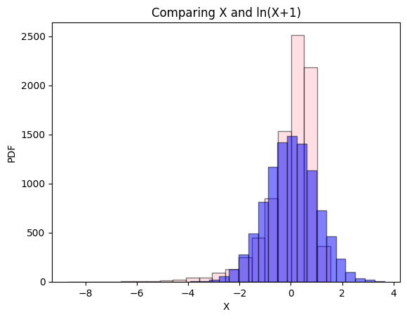

```python
X = torch.distributions.Normal(0,1)
samples_X = X.sample((10000,))
samples_Y = torch.log(samples_X+1)
plt.hist(samples_Y,edgecolor='k',color='pink',bins=20,alpha=0.5)
plt.hist(samples_X,edgecolor='k',color='blue',bins=20,alpha=0.5)
plt.xlabel("X")
plt.ylabel("PDF")
plt.title("Comparing X and ln(X+1)")
plt.show()
```

### 18. Generating Random Numbers

#### Q1 (a) Generate 10,000 samples from a uniform distribution U(0,1).

#### (b) Transform these samples to generate exponential random variables with parameter λ = 2.

#### (c) Plot a histogram of the generated exponential random variables.

```python
uniform = torch.distributions.Uniform(0,1)
samples = uniform.sample((10000,))
lamda = 2
exp = -torch.log(1-samples)/lamda
plt.hist(exp,bins=20,edgecolor='k',color='m')
plt.show()
```

[output not shown]

#### Q2 Given an exponential distribution with rate parameter λ=3.

#### Write a Python function that:

#### (a) Generates a single exponential random variable using inverse transform sampling. Uses the transformation X=− 1/λ ln(1−U), where U is a uniform random number between 0 and 1 and returns the generated exponential random variable.

```python
def generate_exponential_random_variable(lam):
    U = torch.distributions.Uniform(0, 1).sample((1,))
    X = - (1 / lam) * torch.log(1 - U)
    return X

lambda_param = 3
exponential_random_variable = generate_exponential_random_variable(lambda_param)
print("Generated Exponential Random Variable:", round(exponential_random_variable.item(),2))
```

```
Generated Exponential Random Variable: 0.32
```

#### Q3 Write a Python function that:

#### (a). Generates N random samples from a uniform distribution U(0,1) and transforms the samples into exponential random variables with rate λ=5 using inverse transform sampling.

#### (b) Apply a nonlinear transformation Z = X² to each generated exponential random variable X.

#### (c) Calculates and returns the following:

#### A. The proportion of values in Z that exceed a threshold t (provided as a function parameter).

#### B. The sample mean and sample variance of both X and Z.

```python
import torch

def RNG(N, t):
    # Generating Uniform(0,1) random variables
    uniform_dist = torch.distributions.Uniform(0, 1)
    A = uniform_dist.sample((N,))

    # Transforming to exponential distribution with λ = 5
    λ = 5
    X = -torch.log(1 - A) / λ

    # Applying nonlinear transformation: Z = X²
    Z = X**2

    # Computing proportion of Z values greater than threshold t
    proportion_Z = (Z > t).sum().item() / len(Z)

    # Computing sample statistics
    mean_X, var_X = round(X.mean().item(), 4), round(X.var().item(), 4)
    mean_Z, var_Z = round(Z.mean().item(), 4), round(Z.var().item(), 4)

    # Displaying results
    print(f"Proportion of Z values exceeding {t}: {proportion_Z:.4f}")
    print(f"Mean & Variance of X: {mean_X}, {var_X}")
    print(f"Mean & Variance of Z: {mean_Z}, {var_Z}")

    return proportion_Z, mean_X, var_X, mean_Z, var_Z


#main_#
RNG(10000,0.2)
```

```
Proportion of Z values exceeding 0.2: 0.1063
Mean & Variance of X: 0.1987, 0.0404
Mean & Variance of Z: 0.0799, 0.0316
```

```
(0.1063, 0.1987, 0.0404, 0.0799, 0.0316)
```